# Lake Water Quality Analysis

Avery Driscoll

2/23/2022

# LAGOS Analysis

## Loading in data

First download and then specifically grab the locus (or site lat longs)

```r
#Load in lagos
lagos <- lagosne_load()
#Grab the lake centroid info
lake_centers <- lagos$locus

# Make an sf object
spatial_lakes <- st_as_sf(lake_centers,coords=c('nhd_long','nhd_lat'),
                          crs=4326)

#Grab the water quality data
nutr <- lagos$epi_nutr
```

Subset columns nutr to only keep key info that we want

```r
clarity_only <- nutr %>%
  dplyr::select(lagoslakeid,sampledate,chla,doc,secchi) %>%
  mutate(sampledate = as.character(sampledate) %>% ymd(.))
```

Keep sites with at least 200 observations

```r
chla_secchi <- clarity_only %>%
  filter(!is.na(chla),
         !is.na(secchi))

# Keep only the lakes with at least 200 observations of secchi and chla
chla_secchi_200 <- chla_secchi %>%
  group_by(lagoslakeid) %>%
  mutate(count = n()) %>%
  filter(count > 200)
```

Join water quality data to spatial data

```r
spatial_200 <- inner_join(spatial_lakes,chla_secchi_200 %>%
                            distinct(lagoslakeid,.keep_all=T),
                          by='lagoslakeid')
```

Mean Chl_a map

```r
# Take the mean chl_a and secchi by lake
mean_values_200 <- chla_secchi_200 %>%
  # Take summary by lake id
  group_by(lagoslakeid) %>%
  # take mean chl_a per lake id
  summarize(mean_chl = mean(chla,na.rm=T),
            mean_secchi=mean(secchi,na.rm=T)) %>%
  #Get rid of NAs
  filter(!is.na(mean_chl),
         !is.na(mean_secchi)) %>%
  # Take the log base 10 of the mean_chl
  mutate(log10_mean_chl = log10(mean_chl))

#Join datasets
mean_spatial <- inner_join(spatial_lakes,mean_values_200,
                          by='lagoslakeid')

#Make a map
mapview(mean_spatial,zcol='mean_chl')
```

[interactive chart not shown]

# Class work

## 1) What is the correlation between Secchi Disk Depth and Chlorophyll a for sites with at least 200 observations?

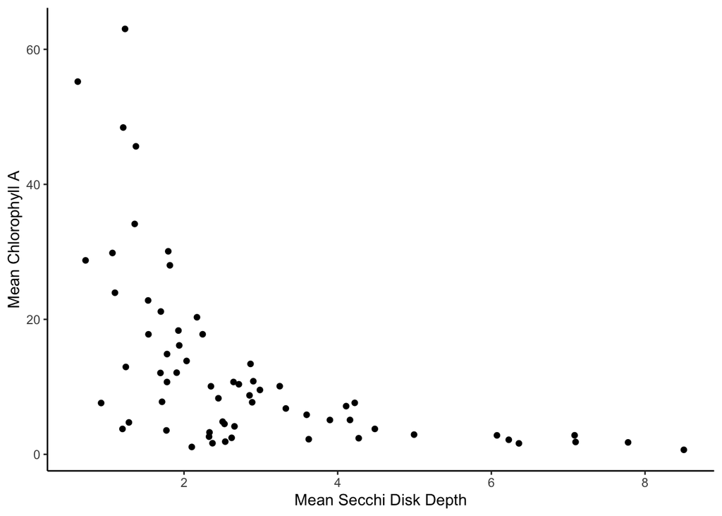

```r
#Scatterplot of chlorophyll A by secchi disk depth
ggplot(mean_values_200, aes(x = mean_secchi, y = mean_chl)) +
  geom_point() + theme_classic() +
  ylab("Mean Chlorophyll A") + xlab("Mean Secchi Disk Depth")
```

## Why might this be the case?

Chlorophyll A and Secchi disk depth are inversely related, which is unsurprising given that Chlorophyll A is an indicator of algae growth in the water and Secchi disk depth represents how visually clear the water is. A lake with extensive algae growth is likely to be more difficult to see through.

## 2) What states have the most data?

Minnesota, Wisconsin, New York, Rhode Island, and Missouri are the five states with the most data. The code below shows how we identified these states.

### 2a) First, make a lagos spatial dataset that has the total number of observations per site.

```r
#Count the number of observations per site
count <- chla_secchi %>%
  filter(!(is.na(chla) & is.na(secchi))) %>% #be sure that there aren't any rows that don't have either measurement (there are not)
  group_by(lagoslakeid) %>% #group by lake ID (site)
  summarize(n_observations = length(chla)) #count the number of rows in each group

#Merge the count data with the spatial data. Inner join works here because all of the sites in the count dataframe are represented in the spatial lakes object. Transform to match the crs used for the state boundaries in the previous assignnment
count_spatial <- inner_join(spatial_lakes, count, by='lagoslakeid') %>%
  st_transform(2163)
```

### 2b) Second, join this point dataset to a dataframe containing the state boundaries.

```r
#Pull the state boundary polygons and transform to match the projection of the lagos data
states <- us_states() %>%
  st_transform(2163)

#st_join is the general function for merging two spatial data objects. Here, we use the argument join = st_within to specify the point data must be contained within the state polygons
count_spatial <- st_join(count_spatial, states, join = st_within)
```

### 2c) Finally, group by state and count observations within each state.

```r
#The LAGOS NE dataset, which we're using, only contains data for 17 states across the northeast and midwest US. This code adds up all the observations for each state and organizes the data by the number of observations.
count_summary <- count_spatial %>%
  group_by(state_name) %>%
  summarize(state_observations = sum(n_observations)) %>%
  arrange(-state_observations)

#print the first five rows (without the geometry information), showing the states with the most observations:
st_drop_geometry(count_summary[1:5, 1:2])
```

```
## # A tibble: 5 × 2
##   state_name   state_observations
## * <chr>                     <int>
## 1 Minnesota                 78455
## 2 Wisconsin                 20825
## 3 New York                  18046
## 4 Rhode Island              11657
## 5 Missouri                  11442
```

## 3 Is there a spatial pattern in Secchi disk depth for lakes with at least 200 observations?

Generally, lakes in northern Wisconsin and the Northeast tend to be clearest, and lakes in Missouri, Indiana, and Minnesota are less clear. Lakes in close spatial proximity also appear to have more similar secchi disk depths, suggesting some spatial autocorrelation in the data.

```r
#We can use the mean_spatial dataframe that we made earlier that summarizes mean chla and secchi disk depth for lakes with >200 observations. This map shows the raw values:
mapview(mean_spatial, zcol='mean_secchi', layer.name = "Secchi disk depth (m)")
```

[interactive chart not shown]

```r
#Plotting the log values may also make comparisons easier:
mean_spatial %>%
  mutate(mean_secchi_log10 = log10(mean_secchi)) %>%
  mapview(., zcol = "mean_secchi_log10", layer.name = "log10 secchi disk depth")
```

[interactive chart not shown]